# Sliced Episode 10: Animal adoption

John Thompson

2021-10-02

# Introduction

The data for episode 10 of *Sliced*, the second round of the play-offs, relates to the adoption of abandoned or unwanted pets. Given information about the animal, such as its breed and age, the competitors had to predict a three class outcome, either, adoption, transfer or what is euphemistically called ‘no outcome’, which in reality means that the animal was put down (another euphemism).

The data can be downloaded from https://www.kaggle.com/c/sliced-s01e10-playoffs-2/overview/description.

In truth this is not a particularly interesting dataset. There are few features and apart from the three class outcome, it is a very standard problem.

In an attempt to make it more interesting, I decided to experiment with the `mlr3` package. This is a competitor to `tidymodels` in the sense that it offers another way of organising machine learning workflows. I do not like `tidymodels` because I feel that it encourages a black box mentality, so I was interested to see if I have the same reaction to `mlr3`.

In this post, I will concentrate of the application of `mlr3` to the animal adoption data without giving a detailed explanation of the syntax. If you have never seen `mlr3` before, you might find it helpful to start by reading my methods post entitled `Methods: Introduction to mlr3`. In that post I explain how the structure of `mlr3` is dependent on object orientated programming and in particular, the `R6` package.

# Reading the data:

It is my practice to read the data asis and to immediately save it in rds format within a directory called data/rData. For details of the way that I organise my analyses you should read my post called `Sliced Methods Overview`.

```r
# --- setup: libraries & options ------------------------
library(tidyverse)

theme_set( theme_light())

# --- set home directory -------------------------------
home <- "C:/Projects/kaggle/sliced/s01-e10"

# --- read downloaded data -----------------------------
trainRawDF <- readRDS( file.path(home, "data/rData/train.rds") )

testRawDF <- readRDS( file.path(home, "data/rData/test.rds") )
```

# Data Exploration:

I usually start by summarising the training data with the `skimr` package.

```r
# --- summarise the training set -----------------------
skimr::skim(trainRawDF)
```

## Response

The majority of the animals are adopted

```r
# --- outcomes ----------------------------------------
trainRawDF %>%
  count( outcome_type ) %>%
  mutate( pct = 100*n/sum(n))
```

```
## # A tibble: 3 x 3
##   outcome_type     n   pct
##   <chr>        <int> <dbl>
## 1 adoption     33275 61.2
## 2 no outcome    4735  8.70
## 3 transfer     16398 30.1
```

## Predictors

As I have often done in previous episodes of *Spliced*, I have written a function for plotting the predictors; this time the function is called `plot_animals()`. The code is given in as a appendix at the end of this post.

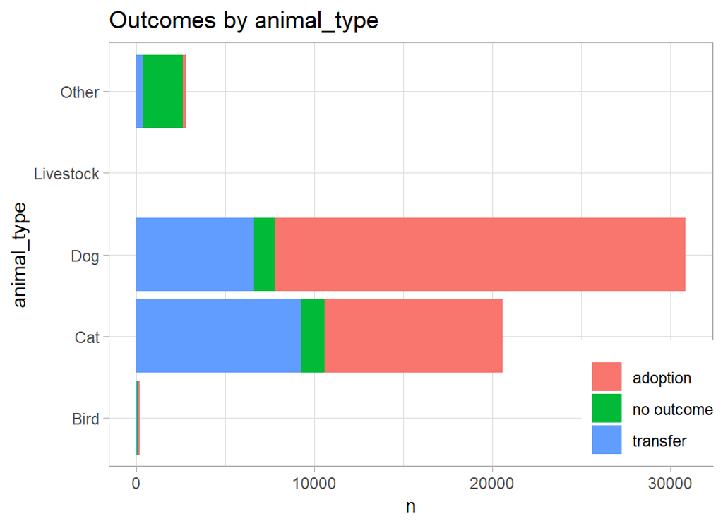

```r
# --- categories of animal type ---------------------------
trainRawDF %>%
  plot_animals(animal_type)
```

Two thoughts come to mind.

- the features relevant to prediction for cats, dogs and birds will be very different
- the bird & livestock categories are very small

I will split the data into three parts; cat, dog & (other+bird+livestock) and I will predict separately within each of the three.

## Data cleaning

In preparation for the analysis, I need to process the date on which the outcome occurred, which I’ll convert to a month and a year, and I need to clean the ages, which are variously recorded in days or months or years. I will not use the data_of_birth.

There are a handful of missing ages that I replace using the median age for that type of animal.

```r
# --- clean the training data --------------------------------
library(lubridate)

trainRawDF %>%
   mutate( outcome_type = factor(outcome_type),
           # --- date to month, year and time of day ---------
           month         = as.numeric(month(datetime)),
           year          = as.numeric(year(datetime)),
           hour          = as.numeric(hour(datetime)),
           # --- numerical part of the age field -------------
           age_number    = as.numeric(str_extract(
             age_upon_outcome, "[:digit:]+")),
           # --- test part of the age field ------------------
           age_unit      = str_extract(
             age_upon_outcome, "[a-z]+"),
           unit          = substr(age_unit, 1, 1)) %>%
  # --- calculate age in years -------------------------------
  mutate(   age = age_number*(unit == "y") +
                  age_number*(unit == "m")/12 +
                  age_number*(unit == "w")/52 +
                  age_number*(unit == "d")/365 ) %>%
  select(-age_upon_outcome, -age_number, -age_unit, -unit,
         -datetime, -date_of_birth, -name) -> prepDF

# median impute the missing ages ------------------------------
# --- median = 2 for dogs -------------------------------------
mDog <- median(prepDF$age[prepDF$animal_type=="Dog"], na.rm=TRUE)

prepDF$age[is.na(prepDF$age) & prepDF$animal_type=="Dog"] <- mDog

# --- median = 1 for bats -------------------------------------
mBat <- median(prepDF$age[prepDF$breed=="Bat Mix"], na.rm=TRUE)

prepDF$age[is.na(prepDF$age) & prepDF$breed=="Bat Mix"] <- mBat
```

## Cats

Skimming the data on cats shows that there are 20,561 rows, 70 breeds and 201 colours.

```r
skimr::skim(prepDF %>% filter(animal_type == "Cat"))
```

Here are the common cat breeds

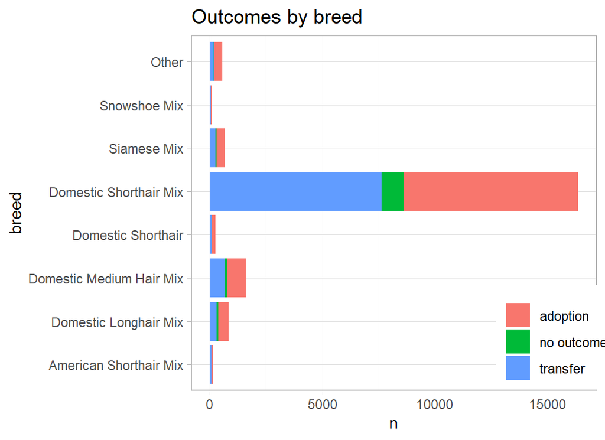

```r
# --- categories of cat breed ---------------------------
prepDF %>%
  filter( animal_type == "Cat") %>%
  mutate( breed = fct_lump(breed, prop=0.005)) %>%
  plot_animals(breed)
```

The common colours are not obviously related to outcome.

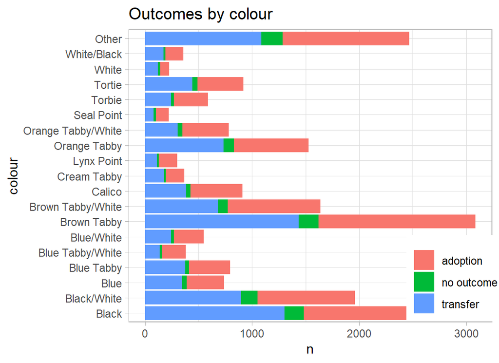

```r
# --- categories of cat breed ---------------------------
prepDF %>%
  filter( animal_type == "Cat") %>%
  mutate( colour = fct_lump(color, prop=0.01)) %>%
  plot_animals(colour)
```

Neutered cats are more likely to get adopted

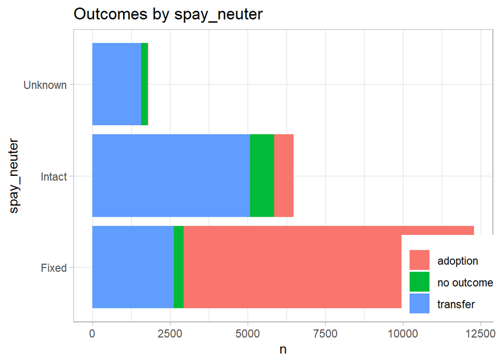

```r
# --- neutering in cats ---------------------------------
prepDF %>%
  filter( animal_type == "Cat") %>%
  plot_animals(spay_neuter)
```

The cat’s sex is not particularly predictive, but when the sex is unknown it is unlikely that the cat was adopted.

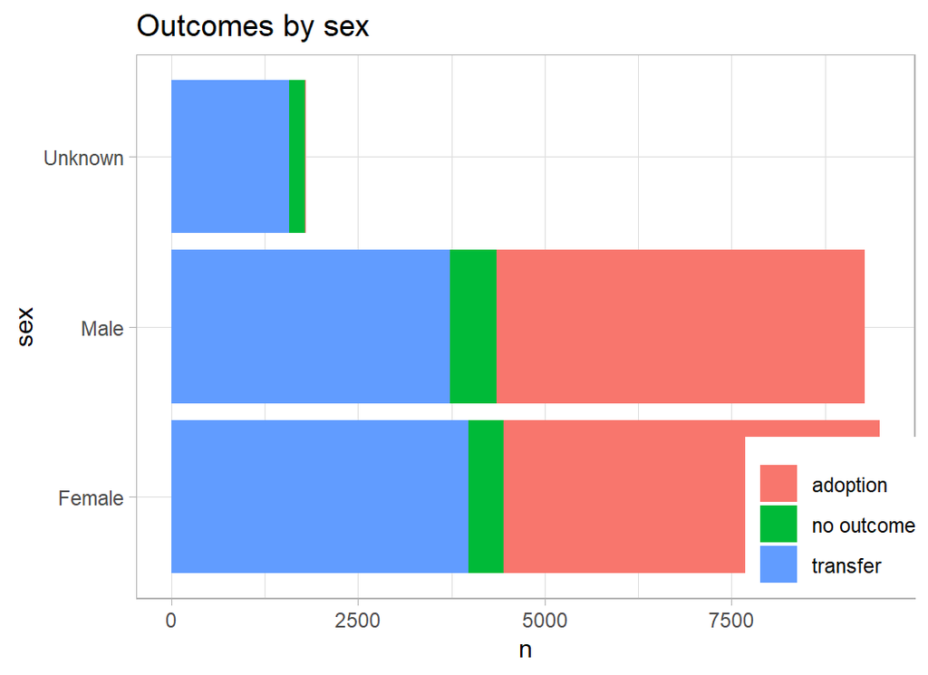

```r
prepDF %>%
  filter( animal_type == "Cat") %>%
  plot_animals(sex)
```

Age is recorded is days, weeks, months or years but has been records as fractions of a year.

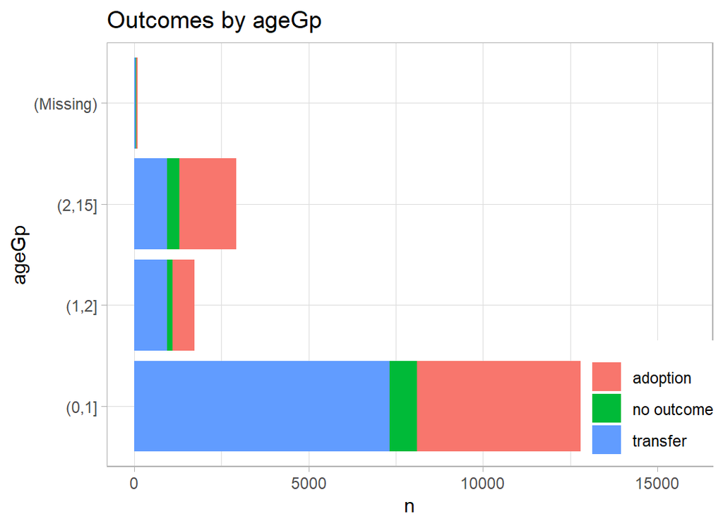

```r
prepDF %>%
  filter( animal_type == "Cat") %>%
  mutate( ageGp = cut(age, breaks=c(0, 1, 2, 15))) %>%
  plot_animals(ageGp)
```

The outcomes vary considerably across the year with a larger proportion of transfers in April and May.

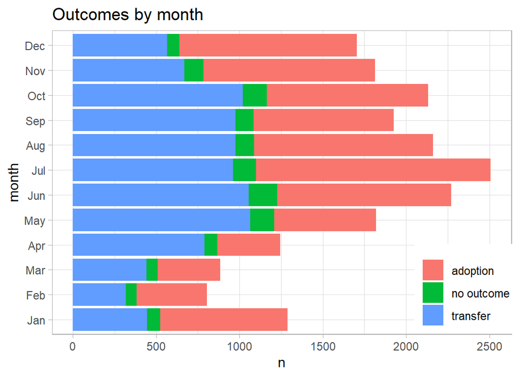

```r
prepDF %>%
  filter( animal_type == "Cat") %>%
  mutate( month = factor(month, levels=1:12, labels=month.abb)) %>%
  plot_animals(month)
```

Transfers are less common in recent years

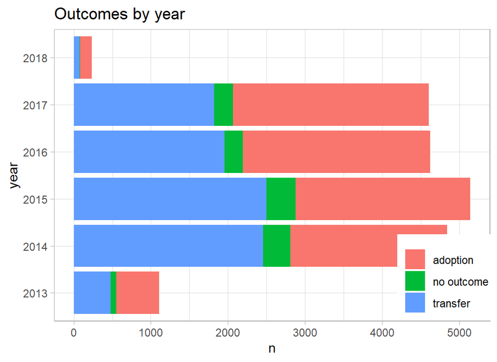

```r
prepDF %>%
  filter( animal_type == "Cat") %>%
  mutate( year = factor(year)) %>%
  plot_animals(year)
```

It seems like cheating, but work patterns clearly help predict outcome. Transfers occur at 9am, but people call after work to collect their adopted cat.

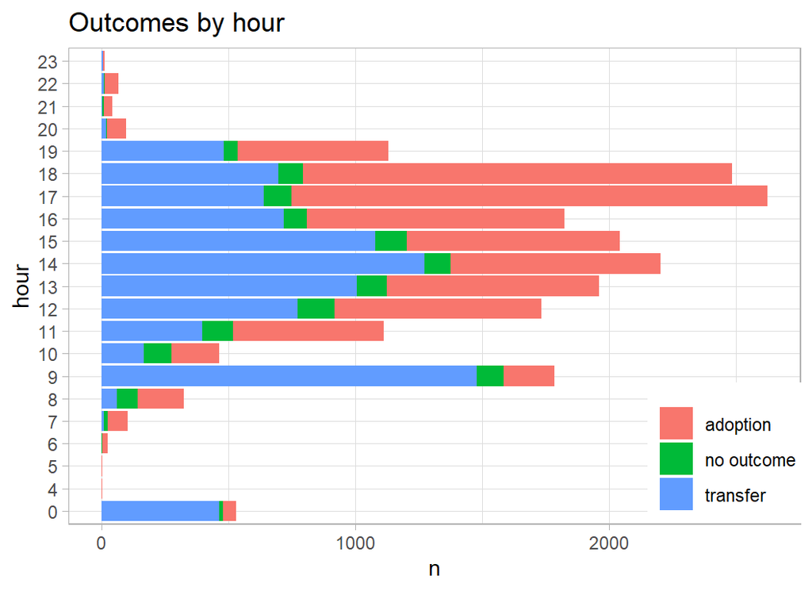

```r
prepDF %>%
  filter( animal_type == "Cat") %>%
  mutate( hour = factor(hour)) %>%
  plot_animals(hour)
```

## Preprocessing cats

I’ll add some indicator variables for the common colours and breeds and prepare a data set for training the cat model.

```r
# --- function to add indicators ----------------------------
add_indicators <- function(thisDF, col, keywords, prefix) {
  for( j in seq_along(keywords) ) {
     thisDF[[ paste(prefix, j, sep="")]] <-
       as.numeric( str_detect(tolower(thisDF[[col]]), keywords[j]))
  }
  return(thisDF)
}
# --- select the cats ---------------------------------------
prepDF %>%
  filter(animal_type == "Cat") %>%
  select( -animal_type ) -> prepCatDF

# --- indicators for key words in breed ---------------------
add_indicators(prepCatDF,
               col = "breed",
               keywords = c("domestic", "mix", "short",
                           "medium", "long"),
               prefix = "B") -> prepCatDF

# --- indicators for key words in colour ---------------------
add_indicators(prepCatDF,
               col = "color",
               keywords = c("tabby", "black", "white",
                            "brown", "blue"),
               prefix = "C") -> prepCatDF

# --- indicators for sex -------------------------------------
add_indicators(prepCatDF,
               col = "sex",
               keywords = sort(unique(tolower(prepCatDF$sex))),
               prefix = "S") -> prepCatDF

# --- indicators for neuter ---------------------------------
add_indicators(prepCatDF,
               col = "spay_neuter",
               keywords = sort(unique(tolower(prepCatDF$spay_neuter))),
               prefix = "N") -> prepCatDF

# --- keep predictors ---------------------------------------
prepCatDF %>%
  select( -breed, -color, -sex, -spay_neuter,  -id) -> trainCatDF
```

# mlr3

Now I will use `mlr3` to model the cat data. For an explanation of how `mlr3` works, you should read my post entitled `Methods: Introduction to mlr3`. Briefly, the terminology is  
* task … the data  
* learner … the method of model building  
* measure … the performance metric

Rather like loading the `tidyverse`, loading `mlr3verse` makes available all of the essential packages in the ecosystem.

I want to do something simple, so that I do not have to explain the method at the same time as introducing `mlr3`, so I’ll use `xgboost`

In the following code, I define the data, select a learner, train the model, look at the results, makes predictions and inspect the confusion matrix; I end by choosing the logloss as my performance metric and I evaluate the logloss on the training data.

Once you understand the syntax, the code is concise and logical.

```r
# --- load the important mlr3 packages -----------------------
library(mlr3verse)

# --- define the task ----------------------------------------
myTask <- TaskClassif$new( id      = "cat_adoption",
                           backend = trainCatDF,
                           target  = "outcome_type")

# --- select the learner -------------------------------------
myLearner <- lrn("classif.xgboost",
                 nrounds     = 100,
                 objective   = "multi:softprob",
                 eval_metric = "mlogloss")

# --- train the model ----------------------------------------
myLearner$train(task = myTask)

# --- look at the result -------------------------------------
myLearner$model
```

```
## ##### xgb.Booster
## raw: 967.8 Kb
## call:
##   xgboost::xgb.train(data = data, nrounds = 100L, watchlist = list(
##     train = <pointer: 0x00000000183aad40>), verbose = 0L, nthread = 1L,
##     objective = "multi:softprob", eval_metric = "mlogloss", num_class = 3L)
## params (as set within xgb.train):
##   nthread = "1", objective = "multi:softprob", eval_metric = "mlogloss", num_class = "3", validate_parameters = "TRUE"
## xgb.attributes:
##   niter
## callbacks:
##   cb.evaluation.log()
## # of features: 20
## niter: 100
## nfeatures : 20
## evaluation_log:
##     iter train_mlogloss
##        1       0.862690
##        2       0.727069
## ---
##       99       0.301958
##      100       0.300915
```

```r
# --- predict and show the confusion matrix ------------------
myPredictions <- myLearner$predict(myTask)
myPredictions$confusion
```

```
##             truth
## response     adoption no outcome transfer
##   adoption       9370        166     1119
##   no outcome       13        630       37
##   transfer        593        505     8128
```

```r
# --- logloss requires probability predictions ---------------
myMeasure              <- msr("classif.logloss")
myLearner$predict_type <- "prob"
myPredictions          <- myLearner$predict(myTask)
myPredictions$score(myMeasure)
```

```
## classif.logloss
##       0.3009133
```

The in-sample logloss is 0.30. It only relates to cats, but for comparison, the leading model in the competition scored a test sample logloss of 0.36 over all animals.

I can access the results in the normal way since `myLearner$model` contains the usual structure returned by xgboost.

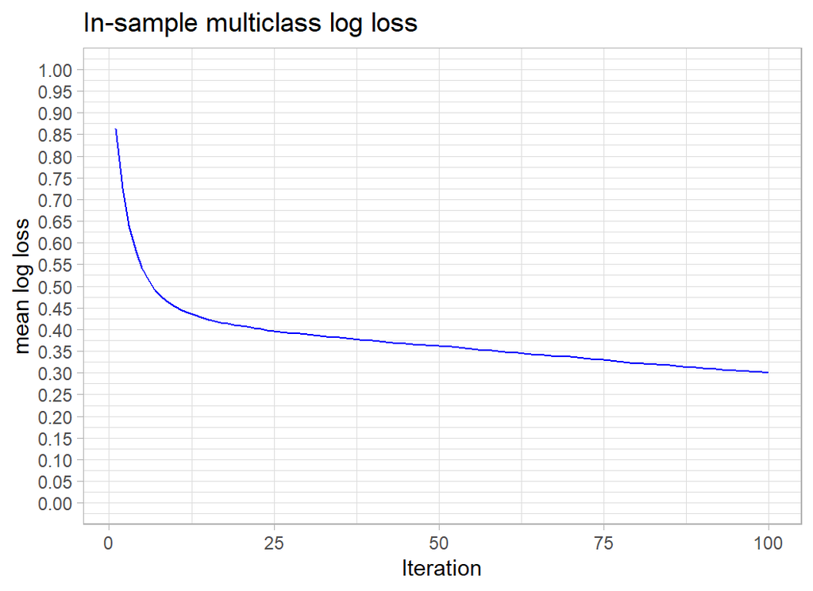

```r
myLearner$model$evaluation_log %>%
    ggplot( aes(x=iter, y=train_mlogloss)) +
    geom_line(colour="blue") +
    scale_y_continuous( limits = c(0, 1), breaks=seq(0, 1, by=.05)) +
    labs(x="Iteration", y="mean log loss",
         title="In-sample multiclass log loss")
```

I need to check if the in-sample logloss has overfitted, so I’ll use cross-validation with 5 folds and I’ll speed things up by running the folds in multiple sessions using the `future` package. When you use multiple sessions each one runs independently and has its own copy of the data. `mlr3` also allows multiple cores, when the cores access the same data, but this is not available in Windows.

```r
future::plan("multisession")

# --- define CV and apply to the data -----------------------
set.seed(9766)
myCV <- rsmp("cv", folds=5)
myCV$instantiate(task = myTask)

# --- run the cross validation ------------------------------
rsFit <- resample( task       = myTask,
                   learner    = myLearner,
                   resampling = myCV)
```

```
## INFO  [14:39:09.493] [mlr3]  Applying learner 'classif.xgboost' on task 'cat_adoption' (iter 5/5)
## INFO  [14:39:10.724] [mlr3]  Applying learner 'classif.xgboost' on task 'cat_adoption' (iter 2/5)
## INFO  [14:39:12.054] [mlr3]  Applying learner 'classif.xgboost' on task 'cat_adoption' (iter 4/5)
## INFO  [14:39:13.442] [mlr3]  Applying learner 'classif.xgboost' on task 'cat_adoption' (iter 3/5)
## INFO  [14:39:14.883] [mlr3]  Applying learner 'classif.xgboost' on task 'cat_adoption' (iter 1/5)
```

```r
# --- show individual and aggregate logloss -----------------
rsFit$score(myMeasure)
```

```
##                 task      task_id                     learner      learner_id
## 1: <TaskClassif[47]> cat_adoption <LearnerClassifXgboost[35]> classif.xgboost
## 2: <TaskClassif[47]> cat_adoption <LearnerClassifXgboost[35]> classif.xgboost
## 3: <TaskClassif[47]> cat_adoption <LearnerClassifXgboost[35]> classif.xgboost
## 4: <TaskClassif[47]> cat_adoption <LearnerClassifXgboost[35]> classif.xgboost
## 5: <TaskClassif[47]> cat_adoption <LearnerClassifXgboost[35]> classif.xgboost
##            resampling resampling_id iteration              prediction
## 1: <ResamplingCV[19]>            cv         1 <PredictionClassif[19]>
## 2: <ResamplingCV[19]>            cv         2 <PredictionClassif[19]>
## 3: <ResamplingCV[19]>            cv         3 <PredictionClassif[19]>
## 4: <ResamplingCV[19]>            cv         4 <PredictionClassif[19]>
## 5: <ResamplingCV[19]>            cv         5 <PredictionClassif[19]>
##    classif.logloss
## 1:       0.4467382
## 2:       0.4358017
## 3:       0.4627691
## 4:       0.4434847
## 5:       0.4586902
```

```r
rsFit$aggregate(myMeasure)
```

```
## classif.logloss
##       0.4494968
```

The cross-validated logloss is 0.45, so the in-sample result was very optimistic and the model is actually quite some way from the top of the leaderboard.

I will try some classic machine learning hyperparameter tuning, even though I don’t really approve, because it serves to demonstrate more features of `mlr3`. `myLearner$param_set` contains the values of the parameters that were used to fit the model.

```r
myLearner$param_set
```

[output not shown]

[output cut: 64 more lines]

[output not shown]

I will reduce the learning rate from 0.3 to 0.1 and simultaneously try tuning the number of iterations (rounds) and the max_depth parameter. The method that I’ve chosen takes 10 random pairs of parameter values within my specified ranges.

```r
myLearner$predict_type <- "prob"

# --- set hyperparameters -----------------------------------
myLearner$param_set$values           <- list(eta=0.1)
myLearner$param_set$values$nrounds   <- to_tune(50, 500)
myLearner$param_set$values$max_depth <- to_tune(3, 6)

# --- run tuning --------------------------------------------
set.seed(9830)

myTuner <-  tune(
  method     = "random_search",
  task       = myTask,
  learner    = myLearner,
  resampling = myCV,
  measure    = myMeasure,
  term_evals = 10,
  batch_size = 5
)
```

I’ve suppressed the output for each iteration as it is long and boring, but here is the final result.

```r
# --- inspect result ----------------------------------------
myTuner
```

```
## <TuningInstanceSingleCrit>
## * State:  Optimized
## * Objective: <ObjectiveTuning:classif.xgboost_on_cat_adoption>
## * Search Space:
## <ParamSet>
##           id    class lower upper nlevels        default value
## 1:   nrounds ParamInt    50   500     451 <NoDefault[3]>
## 2: max_depth ParamInt     3     6       4 <NoDefault[3]>
## * Terminator: <TerminatorEvals>
## * Terminated: TRUE
## * Result:
##    nrounds max_depth learner_param_vals  x_domain classif.logloss
## 1:     361         5          <list[3]> <list[2]>       0.4466408
## * Archive:
## <ArchiveTuning>
##     nrounds max_depth classif.logloss           timestamp batch_nr
##  1:     426         4            0.45 2021-11-02 14:40:17        1
##  2:      97         4            0.46 2021-11-02 14:40:17        1
##  3:      90         5            0.45 2021-11-02 14:40:17        1
##  4:     216         3            0.45 2021-11-02 14:40:17        1
##  5:     349         6            0.45 2021-11-02 14:40:17        1
##  6:     304         6            0.45 2021-11-02 14:41:25        2
##  7:     171         3            0.46 2021-11-02 14:41:25        2
##  8:     467         5            0.45 2021-11-02 14:41:25        2
##  9:     361         5            0.45 2021-11-02 14:41:25        2
## 10:      61         3            0.48 2021-11-02 14:41:25        2
```

# Dogs

I explored and preprocessed the dogs with very similar code to that used for cats so I have hidden the output. I ended with a dataset called `trainDogDF`.

Now I will run an analysis that mirrors that for cats

```r
# --- define the task ----------------------------------------
myTask <- TaskClassif$new( id = "dog_adoption",
                 backend = trainDogDF,
                 target  = "outcome_type")

# --- select the learner -------------------------------------
myLearner <- lrn("classif.xgboost", nrounds = 100,
                 objective="multi:softprob",
                 eval_metric="mlogloss")

# --- train the model ----------------------------------------
myLearner$train(task = myTask)

# --- look at the result -------------------------------------
myLearner$model
```

```
## ##### xgb.Booster
## raw: 956.8 Kb
## call:
##   xgboost::xgb.train(data = data, nrounds = 100L, watchlist = list(
##     train = <pointer: 0x00000000183ab700>), verbose = 0L, nthread = 1L,
##     objective = "multi:softprob", eval_metric = "mlogloss", num_class = 3L)
## params (as set within xgb.train):
##   nthread = "1", objective = "multi:softprob", eval_metric = "mlogloss", num_class = "3", validate_parameters = "TRUE"
## xgb.attributes:
##   niter
## callbacks:
##   cb.evaluation.log()
## # of features: 21
## niter: 100
## nfeatures : 21
## evaluation_log:
##     iter train_mlogloss
##        1       0.877068
##        2       0.749589
## ---
##       99       0.400619
##      100       0.400271
```

```r
# --- predict and show the confusion matrix ------------------
myPredictions <- myLearner$predict(myTask)
myPredictions$confusion
```

```
##             truth
## response     adoption no outcome transfer
##   adoption      22503        588     3634
##   no outcome       48        408       26
##   transfer        494        147     2982
```

```r
# --- logloss requires probability predictions ---------------
myMeasure              <- msr("classif.logloss")
myLearner$predict_type <- "prob"
myPredictions          <- myLearner$predict(myTask)
myPredictions$score(myMeasure)
```

```
## classif.logloss
##       0.4002699
```

```r
# --- define CV and apply to the data -----------------------
set.seed(9126)
myCV <- rsmp("cv", folds=5)
myCV$instantiate(task = myTask)

# --- run the cross validation ------------------------------
rsFit <- resample( task       = myTask,
                   learner    = myLearner,
                   resampling = myCV)
```

```
## INFO  [14:41:35.254] [mlr3]  Applying learner 'classif.xgboost' on task 'dog_adoption' (iter 1/5)
## INFO  [14:41:35.285] [mlr3]  Applying learner 'classif.xgboost' on task 'dog_adoption' (iter 3/5)
## INFO  [14:41:35.330] [mlr3]  Applying learner 'classif.xgboost' on task 'dog_adoption' (iter 5/5)
## INFO  [14:41:35.377] [mlr3]  Applying learner 'classif.xgboost' on task 'dog_adoption' (iter 4/5)
## INFO  [14:41:35.414] [mlr3]  Applying learner 'classif.xgboost' on task 'dog_adoption' (iter 2/5)
```

```r
# --- show individual and aggregate logloss -----------------
rsFit$score(myMeasure)
```

```
##                 task      task_id                     learner      learner_id
## 1: <TaskClassif[47]> dog_adoption <LearnerClassifXgboost[35]> classif.xgboost
## 2: <TaskClassif[47]> dog_adoption <LearnerClassifXgboost[35]> classif.xgboost
## 3: <TaskClassif[47]> dog_adoption <LearnerClassifXgboost[35]> classif.xgboost
## 4: <TaskClassif[47]> dog_adoption <LearnerClassifXgboost[35]> classif.xgboost
## 5: <TaskClassif[47]> dog_adoption <LearnerClassifXgboost[35]> classif.xgboost
##            resampling resampling_id iteration              prediction
## 1: <ResamplingCV[19]>            cv         1 <PredictionClassif[19]>
## 2: <ResamplingCV[19]>            cv         2 <PredictionClassif[19]>
## 3: <ResamplingCV[19]>            cv         3 <PredictionClassif[19]>
## 4: <ResamplingCV[19]>            cv         4 <PredictionClassif[19]>
## 5: <ResamplingCV[19]>            cv         5 <PredictionClassif[19]>
##    classif.logloss
## 1:       0.5142654
## 2:       0.5061514
## 3:       0.5052791
## 4:       0.5274591
## 5:       0.5069654
```

```r
rsFit$aggregate(myMeasure)
```

```
## classif.logloss
##       0.5120241
```

An in-sample logloss of 0.40 and a cross-validated logloss of 0.51. Slightly worse than the result for cats.

I’ll not bother with hyperparameter tuning but move on to the remaining animals, i.e. everything that is not a cat or a dog. I called the data frame `trainRestDF`.

```r
# --- define the task ----------------------------------------
myTask <- TaskClassif$new( id = "remainder_adoption",
                 backend = trainRestDF,
                 target  = "outcome_type")

# --- select the learner -------------------------------------
myLearner <- lrn("classif.xgboost", nrounds = 100,
                 objective="multi:softprob",
                 eval_metric="mlogloss")

# --- train the model ----------------------------------------
myLearner$train(task = myTask)

# --- look at the result -------------------------------------
myLearner$model
```

```
## ##### xgb.Booster
## raw: 541.4 Kb
## call:
##   xgboost::xgb.train(data = data, nrounds = 100L, watchlist = list(
##     train = <pointer: 0x00000000183ab2e0>), verbose = 0L, nthread = 1L,
##     objective = "multi:softprob", eval_metric = "mlogloss", num_class = 3L)
## params (as set within xgb.train):
##   nthread = "1", objective = "multi:softprob", eval_metric = "mlogloss", num_class = "3", validate_parameters = "TRUE"
## xgb.attributes:
##   niter
## callbacks:
##   cb.evaluation.log()
## # of features: 21
## niter: 100
## nfeatures : 21
## evaluation_log:
##     iter train_mlogloss
##        1       0.787281
##        2       0.608884
## ---
##       99       0.030240
##      100       0.029763
```

```r
# --- predict and show the confusion matrix ------------------
myPredictions <- myLearner$predict(myTask)
myPredictions$confusion
```

```
##             truth
## response     adoption no outcome transfer
##   adoption        254          1        0
##   no outcome        0       2287        3
##   transfer          0          3      469
```

```r
# --- logloss requires probability predictions ---------------
myMeasure              <- msr("classif.logloss")
myLearner$predict_type <- "prob"
myPredictions          <- myLearner$predict(myTask)
myPredictions$score(myMeasure)
```

```
## classif.logloss
##      0.02976308
```

```r
# --- define CV and apply to the data -----------------------
set.seed(9126)
myCV <- rsmp("cv", folds=5)
myCV$instantiate(task = myTask)

# --- run the cross validation ------------------------------
rsFit <- resample( task       = myTask,
                   learner    = myLearner,
                   resampling = myCV)
```

```
## INFO  [14:41:45.796] [mlr3]  Applying learner 'classif.xgboost' on task 'remainder_adoption' (iter 3/5)
## INFO  [14:41:45.818] [mlr3]  Applying learner 'classif.xgboost' on task 'remainder_adoption' (iter 5/5)
## INFO  [14:41:46.152] [mlr3]  Applying learner 'classif.xgboost' on task 'remainder_adoption' (iter 1/5)
## INFO  [14:41:46.482] [mlr3]  Applying learner 'classif.xgboost' on task 'remainder_adoption' (iter 2/5)
## INFO  [14:41:46.511] [mlr3]  Applying learner 'classif.xgboost' on task 'remainder_adoption' (iter 4/5)
```

```r
# --- show individual and aggregate logloss -----------------
rsFit$score(myMeasure)
```

```
##                 task            task_id                     learner
## 1: <TaskClassif[47]> remainder_adoption <LearnerClassifXgboost[35]>
## 2: <TaskClassif[47]> remainder_adoption <LearnerClassifXgboost[35]>
## 3: <TaskClassif[47]> remainder_adoption <LearnerClassifXgboost[35]>
## 4: <TaskClassif[47]> remainder_adoption <LearnerClassifXgboost[35]>
## 5: <TaskClassif[47]> remainder_adoption <LearnerClassifXgboost[35]>
##         learner_id         resampling resampling_id iteration
## 1: classif.xgboost <ResamplingCV[19]>            cv         1
## 2: classif.xgboost <ResamplingCV[19]>            cv         2
## 3: classif.xgboost <ResamplingCV[19]>            cv         3
## 4: classif.xgboost <ResamplingCV[19]>            cv         4
## 5: classif.xgboost <ResamplingCV[19]>            cv         5
##                 prediction classif.logloss
## 1: <PredictionClassif[19]>       0.2818141
## 2: <PredictionClassif[19]>       0.2621664
## 3: <PredictionClassif[19]>       0.2059938
## 4: <PredictionClassif[19]>       0.2714324
## 5: <PredictionClassif[19]>       0.2710777
```

```r
rsFit$aggregate(myMeasure)
```

```
## classif.logloss
##       0.2584969
```

The in-sample logloss is 0.03 and the cv logloss is 0.26. Much better performance than for cats or dogs.

# Submission

I’ll make a submission based on the default models. This involves running identical preprocessing to create datasets `testCatDF`, `testDogDF` and `testRestDF`. I’ll hide the code as it really is very similar to what we have already seen.

Now I will refit the default models and predict for the test data

```r
# --- define the task ----------------------------------------
myTask <- TaskClassif$new( id = "cat_adoption",
                 backend = trainCatDF,
                 target  = "outcome_type")

# --- select the learner -------------------------------------
myLearner <- lrn("classif.xgboost", nrounds = 100,
                 objective="multi:softprob",
                 eval_metric="mlogloss")

# --- train the model ----------------------------------------
myLearner$train(task = myTask)

# --- predict for test data ------------------
myLearner$predict_type <- "prob"
myPredictions <- myLearner$predict_newdata(testCatDF, myTask)

myPredictions$print() %>%
  cbind( testCatDF %>% select(id)) %>%
  as_tibble() %>%
  select( id, starts_with("prob")) %>%
  rename( adoption = prob.adoption,
          `no outcome` = `prob.no outcome`,
          transfer = prob.transfer) -> catSubmissionDF
```

```
## <PredictionClassif> for 8781 observations:
##     row_ids truth   response prob.adoption prob.no outcome prob.transfer
##           1  <NA> no outcome  2.294918e-01     0.401341915     0.3691662
##           2  <NA>   transfer  2.702752e-01     0.201223448     0.5285013
##           3  <NA>   transfer  7.491278e-05     0.009217708     0.9907074
## ---
##        8779  <NA>   transfer  8.115178e-04     0.129620299     0.8695682
##        8780  <NA>   transfer  3.984600e-01     0.051707774     0.5498323
##        8781  <NA>   transfer  1.327512e-01     0.112438880     0.7548099
```

```r
# --- define the task ----------------------------------------
myTask <- TaskClassif$new( id = "dog_adoption",
                 backend = trainDogDF,
                 target  = "outcome_type")

# --- select the learner -------------------------------------
myLearner <- lrn("classif.xgboost", nrounds = 100,
                 objective="multi:softprob",
                 eval_metric="mlogloss")

# --- train the model ----------------------------------------
myLearner$train(task = myTask)

# --- predict for test data ------------------
myLearner$predict_type <- "prob"
myPredictions <- myLearner$predict_newdata(testDogDF)

myPredictions$print() %>%
  cbind( testDogDF %>% select(id)) %>%
  as_tibble() %>%
  select( id, starts_with("prob")) %>%
  rename( adoption = prob.adoption,
          `no outcome` = `prob.no outcome`,
          transfer = prob.transfer) -> dogSubmissionDF
```

```
## <PredictionClassif> for 13257 observations:
##     row_ids truth response prob.adoption prob.no outcome prob.transfer
##           1  <NA> adoption     0.9210497     0.004308495    0.07464188
##           2  <NA> adoption     0.6492763     0.014622116    0.33610165
##           3  <NA> adoption     0.7464201     0.006007354    0.24757244
## ---
##       13255  <NA> adoption     0.7975855     0.005738553    0.19667596
##       13256  <NA> adoption     0.8822138     0.054838952    0.06294718
##       13257  <NA> adoption     0.9611011     0.008979154    0.02991984
```

```r
# --- define the task ----------------------------------------
myTask <- TaskClassif$new( id = "remainder_adoption",
                 backend = trainRestDF,
                 target  = "outcome_type")

# --- select the learner -------------------------------------
myLearner <- lrn("classif.xgboost", nrounds = 100,
                 objective="multi:softprob",
                 eval_metric="mlogloss")

# --- train the model ----------------------------------------
myLearner$train(task = myTask)

# --- predict for test data ------------------
myLearner$predict_type <- "prob"
myPredictions <- myLearner$predict_newdata(testRestDF)

myPredictions$print() %>%
  cbind( testRestDF %>% select(id)) %>%
  as_tibble() %>%
  select( id, starts_with("prob")) %>%
  rename( adoption = prob.adoption,
          `no outcome` = `prob.no outcome`,
          transfer = prob.transfer) -> restSubmissionDF
```

```
## <PredictionClassif> for 1279 observations:
##     row_ids truth   response prob.adoption prob.no outcome prob.transfer
##           1  <NA> no outcome  1.454673e-04       0.9998283  2.615419e-05
##           2  <NA> no outcome  9.433312e-04       0.5383162  4.607404e-01
##           3  <NA> no outcome  2.583423e-06       0.9999901  7.328915e-06
## ---
##        1277  <NA>   adoption  7.561390e-01       0.1693181  7.454285e-02
##        1278  <NA> no outcome  4.058437e-05       0.9999217  3.776888e-05
##        1279  <NA> no outcome  8.606400e-06       0.9997879  2.035812e-04
```

```r
bind_rows(catSubmissionDF, dogSubmissionDF, restSubmissionDF) %>%
  write_csv( file.path(home, "temp/submission1.csv"))
```

I entered this file as a late submission and the score on the private leaderboard was 0.47718, which would have put the model in 7th place.

# What we have learned from this example

The point of this analysis was to illustrate the basic use of `mlr3`. I have written an accompanying post, `Methods: Introduction to mlr3`, that gives more explanation of background to the code, including a brief discussion of object orientated programming (OOP) and the R6 package that are both fundamental to `mlr3`.

I have never been a fan of `tidymodels`, so I did not expect to like to `mlr3`. I cannot say that I am a convert, but there were a number of features in `mlr3` that I quite like.

There is nothing in this analysis that I could not have completed very easily with my own code and yet, I did find that using `mlr3` produced neat and concise code. In the accompanying methods post, I discuss a few ways in which I think that `mlr3` improves on `tidymodels`; in brief, they are

- what `mlr3` does is more transparent
- the user remains in greater control of what is happening under the bonnet
- intermediate results are easier to access
- `mlr3` is easier for the user to extend
- `mlr3` has a more coherent design

The big disadvantage of `mlr3` is that, unlike `tidymodels`, it has a steep learning curve. It is hard to follow what is going on without some understanding of OOP and R6.

In this analysis, I have kept the `mlr3` code very basic. The packages will do much more than I have shown, including the creation of very flexible pipelines that combine preprocessing and model fitting. I suspect that no package will be able to offer every option that I would want for preprocessing, so unless it is very easy to add your own pipe operations, I cannot see myself making much use of those facilities.

I will try out the pipe operators of `mlr3` when analysing the data from the next episode of *Sliced*.

# Appendix

Here is the code for the plots that I created for the exploratory analysis of the cat predictors.

```r
# ============================================================
# --- plot_churn() ------------------------------------------
# function to plot a factor and show the percent churn
#   thisDF ... the source of the data
#   col    ... column within thisDF
#
plot_animals <- function(thisDF, col) {
  thisDF %>%
    # --- make a missing category ----------------
    mutate( across({{col}}, fct_explicit_na)) %>%
    # --- calculate the percent churn ----------
    group_by({{col}}, outcome_type) %>%
    summarise( n = n(), .groups="drop" ) %>%
    group_by( {{col}} ) %>%
    ggplot( aes( x=n, y={{col}}, fill=outcome_type)) +
    geom_bar( stat="identity") +
    labs( y = deparse(substitute(col)), fill = NULL,
          title=paste("Outcomes by",
                      deparse(substitute(col))) ) +
    theme( legend.position=c(0.9, 0.15))
}
```